# Reshaping

2015-03-17

# Outline

1. Exporting data from excel
2. using `reshape2`

# Exporting data from Excel

For practice, you can download the buckeye data from my website here: https://jofrhwld.github.io/data/buckeye.xls

What the menus look like will differ from one version of excel to another, and from one operating system to another, but what your goal will be is to save this excel file as a tab-delimited text file. Here’s what that looks like on Excel 2011 for Macs.

With the file open in Excel, go to File > Save as

[figure not shown]

You can choose the file format you’re saving as from a drop down menu towards the bottom:

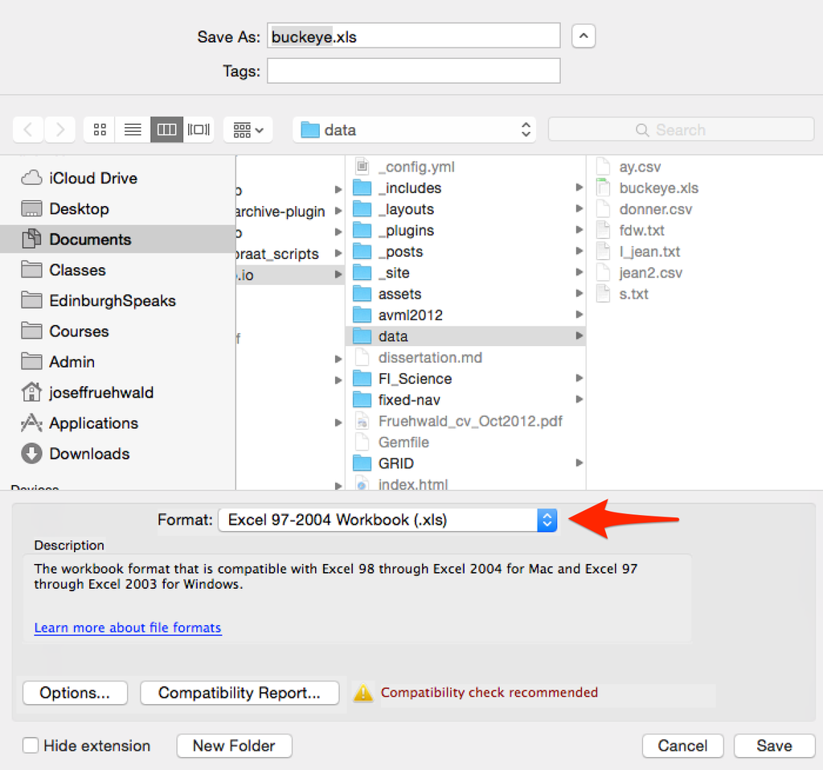

From this drop down menu, you can choose either “csv” (for “comma separated values”), or the Tab Delimited File options. These are both “plain text” formats, and easily read into R using either the `read.delim()` function or the `read.csv()` function.

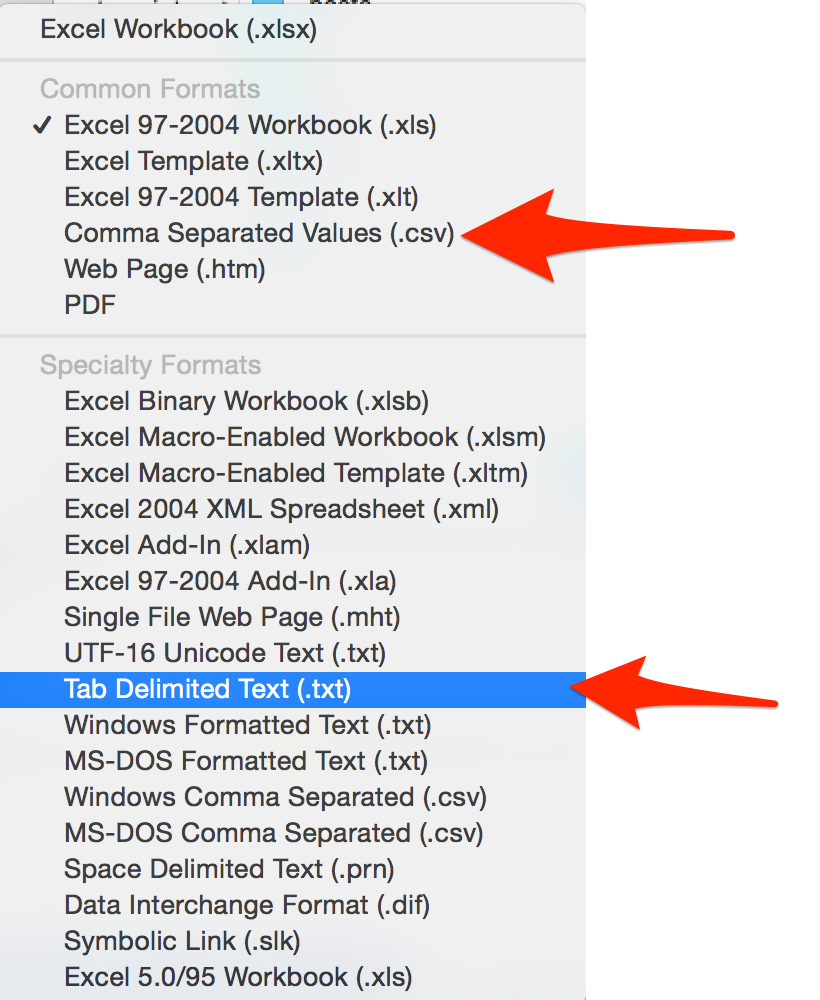

For more on reading data, look back at [this section from week 2’s practical](https://jofrhwld.github.io/teaching/courses/2015_gram_var/practicals/2_r_practical.html#reading-in-data).

# Reshaping Data

Sometimes, you’ll want to take data from columns, and turn them into rows, or vice versa. For example, take the following data frame:

```r
bad_td <- data.frame(speaker = c("speaker1", "speaker2"),
                      past_ret = c(50,45),
                      past_del = c(10, 30),
                      mono_ret = c(100, 75),
                      mono_del = c(200, 90))
print(bad_td)
```

```
##    speaker past_ret past_del mono_ret mono_del
## 1 speaker1       50       10      100      200
## 2 speaker2       45       30       75       90
```

Here, there is one row for each speaker,

- `past_ret` = the number of past tense words each speaker produced with /t/
- `past_del` = the number of past tense words each speaker produced with $\emptyset$
- `mono_ret` = the number of monomorphemic words each speaker produced with /t/
- `mono_del` = the number of monomorphemic words each speaker produced with $\emptyset$

This isn’t a *very* useful data format. Think about how you might ggplot with it. Here’s my best attempt at an informative plot showing the rate at which each speaker pronounce their /t,d/ in past tense forms:

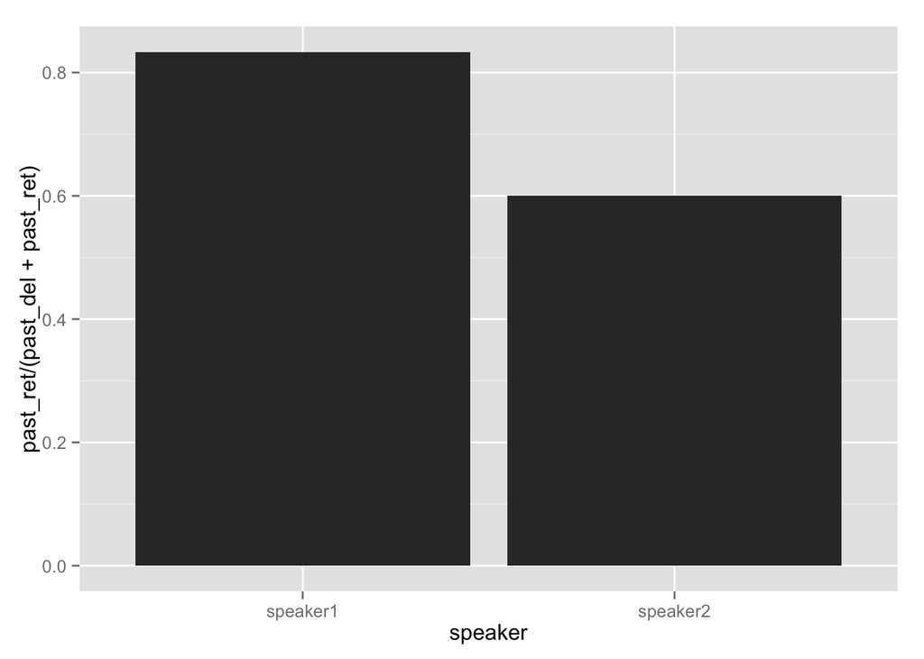

```r
  library(ggplot2)

  ggplot(bad_td, aes(speaker, past_ret/(past_del+past_ret)))+
    geom_bar(stat = "identity")
```

But in a lot of ways, we’re limited by the data format. We’re not, for example, able to easily generate a plot that shows *both* the past tense and monomorphemic data at the same time.

This isn’t just an issue about the kind of data format `ggplot` expects. The structure of the data in `bad_td` is violating principles of “tidy data”.

3. Some principles of tidy data, from [Wickham (2014)](http://vita.had.co.nz/papers/tidy-data.pdf):
1. Each variable forms a column.
2. Each observation forms a row.

The problem with `bad_td` is that the morphological class, and the kind of TD variant are both *variables*, but they’re being used as part of the column name.

## `melt()`

We can easily fix the `bad_td` data frame by using the `melt()` function from the `reshape2` package.

```r
  install.packages("reshape2")
```

The `melt()` function takes three crucial arguments:

1. a data frame to be melted
2. a vector of id variables, that is, columns that should stay just as they are, and
3. a vector of measure variables, that is, columns that should be turned into rows.

It makes sense when you see it in action.

```r
  library(reshape2)

  # before
  print(bad_td)
```

```
##    speaker past_ret past_del mono_ret mono_del
## 1 speaker1       50       10      100      200
## 2 speaker2       45       30       75       90
```

```r
  # you can choose columns either by their name, or numerical index
  better_td <- melt(bad_td, id = "speaker", measure = 2:5)
  print(better_td)
```

```
##    speaker variable value
## 1 speaker1 past_ret    50
## 2 speaker2 past_ret    45
## 3 speaker1 past_del    10
## 4 speaker2 past_del    30
## 5 speaker1 mono_ret   100
## 6 speaker2 mono_ret    75
## 7 speaker1 mono_del   200
## 8 speaker2 mono_del    90
```

By telling `melt()` that the measure variables were `past_ret`, `past_del`, `mono_ret` and `mono_del`, it took the names of those columns and turned it into a variable, and took the values from those columns, and collapsed them into one value column.

## `colsplit()`

This particular example isn’t quite perfect yet. The morphological class and the /t,d/ variant are two different variables, but in `better_td` they’re smashed together into just one column. We can split these this one column into two with the `colsplit()` function, also from `reshape2`.

`colsplit()` takes three arguments:

1. The column that you want to split up.
2. Pattern you want to use to split the column.
3. The names of the new columns that will be created.

```r
  print(better_td)
```

```
##    speaker variable value
## 1 speaker1 past_ret    50
## 2 speaker2 past_ret    45
## 3 speaker1 past_del    10
## 4 speaker2 past_del    30
## 5 speaker1 mono_ret   100
## 6 speaker2 mono_ret    75
## 7 speaker1 mono_del   200
## 8 speaker2 mono_del    90
```

```r
  # split variable based on the underscore, "_", symbol
  new_columns <- colsplit(better_td$variable,
                          pattern = "_",
                          names = c("Gram", "Variant"))

  print(new_columns)
```

```
##   Gram Variant
## 1 past     ret
## 2 past     ret
## 3 past     del
## 4 past     del
## 5 mono     ret
## 6 mono     ret
## 7 mono     del
## 8 mono     del
```

```r
  # stick these new columns onto `better_td` using `cbind()
  best_td <- cbind(better_td, new_columns)
  print(best_td)
```

```
##    speaker variable value Gram Variant
## 1 speaker1 past_ret    50 past     ret
## 2 speaker2 past_ret    45 past     ret
## 3 speaker1 past_del    10 past     del
## 4 speaker2 past_del    30 past     del
## 5 speaker1 mono_ret   100 mono     ret
## 6 speaker2 mono_ret    75 mono     ret
## 7 speaker1 mono_del   200 mono     del
## 8 speaker2 mono_del    90 mono     del
```

Now, we can do some useful `ggplot`ing, or statistical analysis.

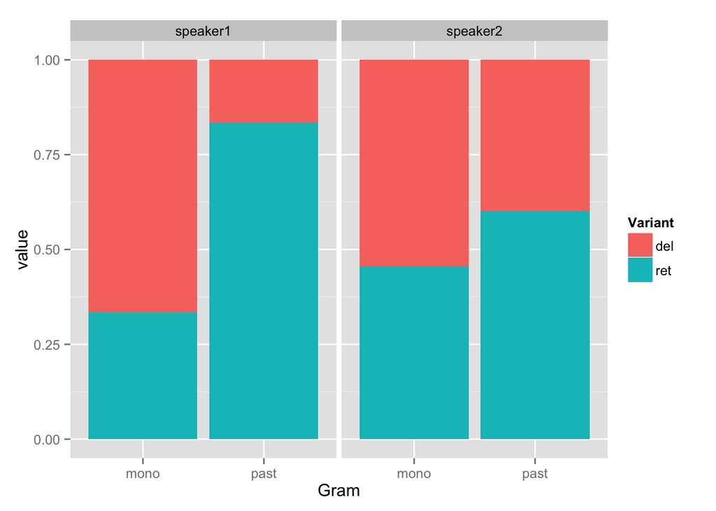

```r
  ggplot(best_td, aes(Gram, value, fill = Variant))+
      geom_bar(stat = "identity", position = "fill")+
      facet_wrap(~speaker)
```

## `dcast()`

Sometimes, though, you might want to go the other way, and turn some row data into column data. You can do this using `dcast()` from the `reshape2` package.

The `dcast()` function takes three arguments:

1. A data frame.
2. A casting formula
3. A value to fill into new cells.

The casting formula looks like this:

var1 + var2 ~ var3

The important part is what comes *before* the tilde, and what comes *after* the tilde.

var1 + var2 ~ var3

The columns that come before the tilde are going to remain just like they are in the original dataframe.

var1 + var2 ~ var3

The column that comes *after* the tilde is going to have its values spread out as new columns. So, let’s take our current `best_td` dataframe:

| speaker | variable | value | Gram | Variant |
| --- | --- | --- | --- | --- |
| speaker1 | past_ret | 50 | past | ret |
| speaker2 | past_ret | 45 | past | ret |
| speaker1 | past_del | 10 | past | del |
| speaker2 | past_del | 30 | past | del |
| speaker1 | mono_ret | 100 | mono | ret |
| speaker2 | mono_ret | 75 | mono | ret |
| speaker1 | mono_del | 200 | mono | del |
| speaker2 | mono_del | 90 | mono | del |

And apply this casting formula to it:

speaker + Gram ~ Variant

This is the basic table we’re going to get out:

| speaker | Gram | del | ret |
| --- | --- | --- | --- |
| speaker1 | mono |  |  |
| speaker1 | past |  |  |
| speaker2 | mono |  |  |
| speaker2 | past |  |  |

Here’s a few more examples of the table templates you’d get from different casting formulas:

| speaker | variable | value | Gram | Variant |
| --- | --- | --- | --- | --- |
| speaker1 | past_ret | 50 | past | ret |
| speaker2 | past_ret | 45 | past | ret |
| speaker1 | past_del | 10 | past | del |
| speaker2 | past_del | 30 | past | del |
| speaker1 | mono_ret | 100 | mono | ret |
| speaker2 | mono_ret | 75 | mono | ret |
| speaker1 | mono_del | 200 | mono | del |
| speaker2 | mono_del | 90 | mono | del |

+

speaker ~ Gram

=

| speaker | mono | past |
| --- | --- | --- |
| speaker1 |  |  |
| speaker2 |  |  |

| speaker | variable | value | Gram | Variant |
| --- | --- | --- | --- | --- |
| speaker1 | past_ret | 50 | past | ret |
| speaker2 | past_ret | 45 | past | ret |
| speaker1 | past_del | 10 | past | del |
| speaker2 | past_del | 30 | past | del |
| speaker1 | mono_ret | 100 | mono | ret |
| speaker2 | mono_ret | 75 | mono | ret |
| speaker1 | mono_del | 200 | mono | del |
| speaker2 | mono_del | 90 | mono | del |

+

Gram + Variant ~ speaker

=

| Gram | Variant | speaker1 | speaker2 |
| --- | --- | --- | --- |
| mono | del |  |  |
| mono | ret |  |  |
| past | del |  |  |
| past | ret |  |  |

The cells in the output of these casting formulas are blank, because you could tell `dcast()` to fill them with any given variable. We probably want to fill them with the data from the `value` column, which would look like this:

```r
  print(best_td)
```

```
##    speaker variable value Gram Variant
## 1 speaker1 past_ret    50 past     ret
## 2 speaker2 past_ret    45 past     ret
## 3 speaker1 past_del    10 past     del
## 4 speaker2 past_del    30 past     del
## 5 speaker1 mono_ret   100 mono     ret
## 6 speaker2 mono_ret    75 mono     ret
## 7 speaker1 mono_del   200 mono     del
## 8 speaker2 mono_del    90 mono     del
```

```r
  dcast(best_td, speaker + Gram ~ Variant, value.var = "value")
```

```
##    speaker Gram del ret
## 1 speaker1 mono 200 100
## 2 speaker1 past  10  50
## 3 speaker2 mono  90  75
## 4 speaker2 past  30  45
```

But we could also do something meaningless like this:

```r
  dcast(best_td, speaker + Gram ~ Variant, value.var = "variable")
```

```
##    speaker Gram      del      ret
## 1 speaker1 mono mono_del mono_ret
## 2 speaker1 past past_del past_ret
## 3 speaker2 mono mono_del mono_ret
## 4 speaker2 past past_del past_ret
```

One reason you might want to to this `dcast`ing is to calculate the proportion ot TD Retention in a slightly weird way.

```r
    wide_td <- dcast(best_td, speaker + Gram ~ Variant, value.var = "value")
    wide_td$prop_ret <- wide_td$ret/(wide_td$ret + wide_td$del)
    print(wide_td)
```

```
##    speaker Gram del ret prop_ret
## 1 speaker1 mono 200 100   0.3333
## 2 speaker1 past  10  50   0.8333
## 3 speaker2 mono  90  75   0.4545
## 4 speaker2 past  30  45   0.6000
```

## Stringing it all together with `dplyr`

Of course, all of these separate steps we’ve done can be strung together with one `dplyr` chain.

```r
  library(dplyr)

  bad_td %>%
    melt(id = "speaker", measure = 2:5)%>%
    cbind(., colsplit(.$variable, "_", names = c("Gram", "Variant")))%>%
    dcast(speaker + Gram ~ Variant)%>%
    mutate(prob_ret = ret/(del+ret))
```

```
##    speaker Gram del ret prob_ret
## 1 speaker1 mono 200 100   0.3333
## 2 speaker1 past  10  50   0.8333
## 3 speaker2 mono  90  75   0.4545
## 4 speaker2 past  30  45   0.6000
```

# A Practical Example

The exercises from this week asked you to:

4. 1. Estimate the rate of Phrase Level Retention and Word Level Retention for each individual speaker in the Buckeye data.
   2. Evaluate how well those estimates compare to the prediction that phrase leve > word level.

## Step 1: Estimate retention for each speaker for each grammatical class

```r
  library(grammarOfVariationData)
  library(dplyr)

  buck_to_use <- buckeye %>%
                  filter(Gram2 %in% c("mono","past")) %>%
                  select(Speaker, Gram2, td)


  retention_rates <- buck_to_use %>%
                        group_by(Speaker, Gram2) %>%
                        summarise(retention = mean(td))

  retention_rates %>% head() %>% print()
```

```
## Source: local data frame [6 x 3]
## Groups: Speaker
##
##   Speaker Gram2 retention
## 1     s01  mono    0.5806
## 2     s01  past    0.7966
## 3     s02  mono    0.5310
## 4     s02  past    0.6042
## 5     s03  mono    0.5149
## 6     s03  past    0.6000
```

## Step 2: Divide mono/past for every speaker.

If we’re assuming the following:

|  | Word Level | Phrase Level |
| --- | --- | --- |
| mono | x | x |
| past | - | x |

Then in order to estimate the word level rate of TD Retention, we need to divide the monomorphemic retention rate by the past tense word rate

5. $\text{word} = \frac{word\times phrase}{phrase} = \frac{mono}{past}$

One easy way to do this with the retention rates we’ve just calculated is to apply this casting formula to it

| Speaker | Gram2 | retention |
| --- | --- | --- |
| s01 | mono | 0.581 |
| s01 | past | 0.797 |
| s02 | mono | 0.531 |
| s02 | past | 0.604 |
| s03 | mono | 0.515 |
| s03 | past | 0.6 |
| … | … | … |

+

Speaker ~ Gram2

, value.var = “retention”

=

| Speaker | mono | past |
| --- | --- | --- |
| s01 | 0.581 | 0.797 |
| s02 | 0.531 | 0.604 |
| s03 | 0.515 | 0.6 |
| … | … | … |

```r
  retention_wide <- dcast(retention_rates, Speaker ~ Gram2, value.var = "retention")
```

Now, it’s easy to divide `mono` by `past` for every speaker.

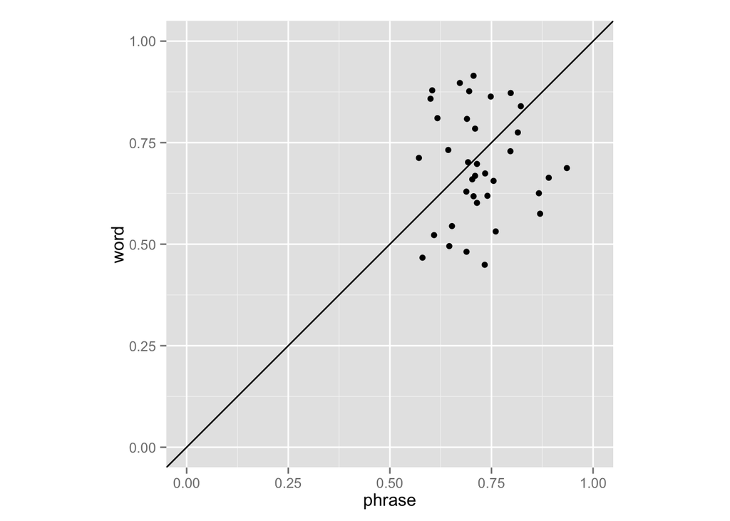

```r
level_estimates <- retention_wide %>%
                      mutate(phrase = past,
                             word = mono/past)

level_estimates %>%
  ggplot(aes(phrase, word))+
    geom_point()+
    geom_abline()+
    ylim(0,1)+
    xlim(0,1)+
    coord_fixed()
```

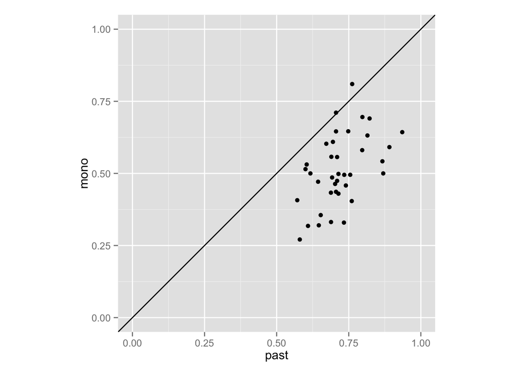

```r
level_estimates %>%
  ggplot(aes(past, mono))+
    geom_point()+
    geom_abline()+
    ylim(0,1)+
    xlim(0,1)+
    coord_fixed()
```

~